# **Siemens - Data Challenge**

Alexander Vosseler

13.09.2019

**Data and statistical target:**

- Data set comprises monthly time series of 18 different products, sold in 13 different countries.
- Observation period is 2012-10 to 2018-09
- Task: 6-step ahead prediction for each time series, i.e. for 2018-10 to 2019-03

**Modeling strategy:**

**1. Descriptive (univar./multivar.) analysis**

- Trends, Seasonal components, Business cycles, Structural breaks, missing values, potential measurement errors
- Check for nonstationarity, test for normality etc.

Data quality issues?

```r
data %>% filter(Demand < 0)
```

| Date | Country | Product | Demand |
| --- | --- | --- | --- |
| 2018-05-01 | Country_0 | Product_14 | -35 |
| 2017-11-01 | Country_2 | Product_0 | -6 |
| 2016-06-01 | Country_5 | Product_6 | -3253 |
| 2016-07-01 | Country_5 | Product_11 | -45 |
| 2016-05-01 | Country_9 | Product_5 | -8 |
| 2014-02-01 | Country_9 | Product_14 | -1 |
| 2013-12-01 | Country_9 | Product_15 | -122 |
| 2014-11-01 | Country_9 | Product_15 | -1 |
| 2015-06-01 | Country_9 | Product_15 | -1 |
| 2013-09-01 | Country_9 | Product_17 | -1 |

[output cut: 2 more lines]

$\rightarrow$ replace observations with missing value (these will be imputed later):

```r
data_cleaned = data %>% mutate(Demand_cleaned = factor(ifelse(Demand < 0 , NA, Demand)))
```

Block of $T = 78$ and $T = 42$ time series

```r
dgr = data_cleaned %>% group_by(Country, Product) %>%
               summarise(n = n(), start_date = min(Date), end = max(Date)) %>%
               arrange(Country, Product) ;
dgr
```

| Country | Product | n | start_date | end |
| --- | --- | --- | --- | --- |
| Country_0 | Product_0 | 78 | 2012-10-01 | 2019-03-01 |
| Country_0 | Product_1 | 78 | 2012-10-01 | 2019-03-01 |
| Country_0 | Product_10 | 78 | 2012-10-01 | 2019-03-01 |
| Country_0 | Product_11 | 78 | 2012-10-01 | 2019-03-01 |
| Country_0 | Product_12 | 78 | 2012-10-01 | 2019-03-01 |
| Country_0 | Product_13 | 78 | 2012-10-01 | 2019-03-01 |
| Country_0 | Product_14 | 78 | 2012-10-01 | 2019-03-01 |
| Country_0 | Product_15 | 78 | 2012-10-01 | 2019-03-01 |
| Country_0 | Product_16 | 78 | 2012-10-01 | 2019-03-01 |
| Country_0 | Product_17 | 78 | 2012-10-01 | 2019-03-01 |

[output cut: 209 more lines]

**Univariate analysis:**

*Example 1:*

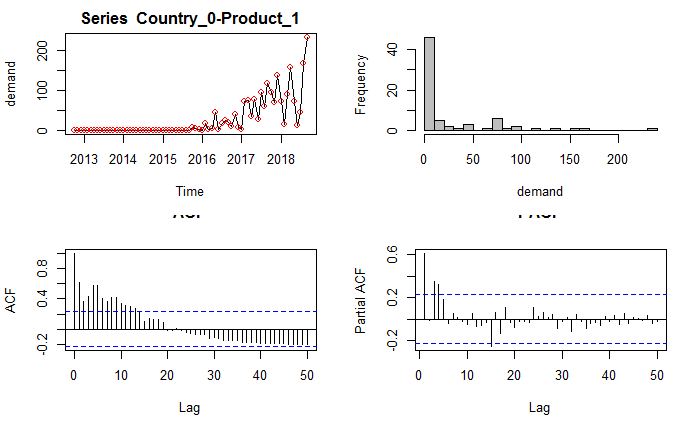

Observe STL decomposition to extract structural components:

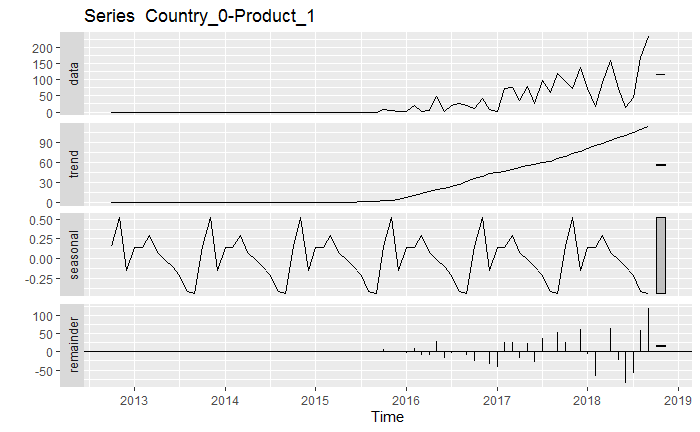

```r
  y_obs %>%
    stl(s.window="periodic", robust=TRUE) %>%
    autoplot(main=paste("Series ", colnames(ts_all)[i]))
```

Example 2:

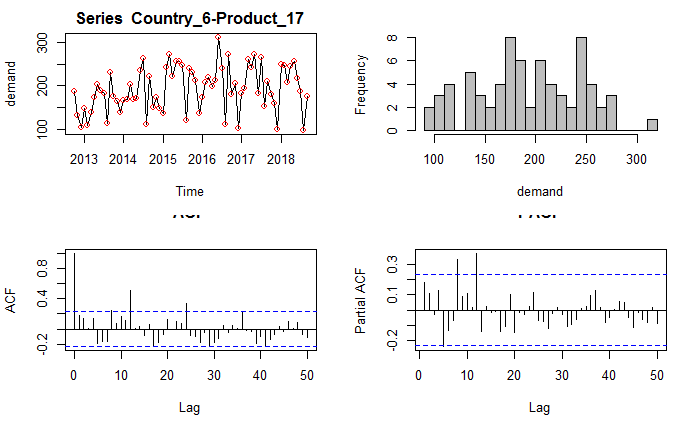

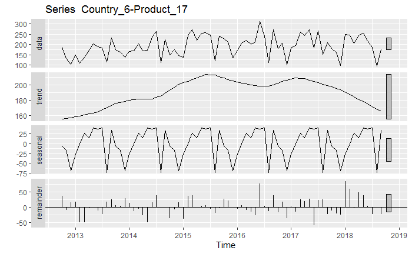

```r
  y_obs %>%
    stl(s.window="periodic", robust=TRUE) %>%
    autoplot(main=paste("Series ", colnames(ts_all)[i]))
```

**So far:**

- Univariate time series exhibit trend, periodic components
- In addition:
  - various tests for normality show that trajectories (DGP) are not approx. normally distr.
  - Some evidence for (non-) seasonal forms of nonstationarity (unit root tests not reported).
  - Relevant for data preprocessing

**2. Data preprocessing (incl. feature engineering) + model selection**

General questions:

- Apply trend/seasonal adjustment and apply model or explicitly incorporate seasonality
- Transform data to approx. normality (Box-Cox etc.) or use models for count data (non-negative support).

**Candidate models:**

- Univariate time series approach
  - Used candidate models:
    - Facebook’s Prophet (GAM)
    - State space models: (STL-) ETS, TBATS (with ARMA erros), Bayesian STS
    - FNN: Single hidden layer with (non) seasonal lagged endogenous input variables
    - Random forest with (non) seasonal lagged endogenous input variables
    - (S)AR(F)IMA models
    - Model Ensembles: Different combination strategies using subsets of candidate models
    - Benchmarks: RwD, Seasonal RwD, Linear time series regression with trend + season
- Multivariate time series approach (to utilize potential crosssectional dependencies)
  - Used candidates: BVAR (after seasonal adjustment)
- (Dynamic) Panel data approach (to utilize hierarchical country - product structure of the data)

**Model selection**

- Finally used set of candidates:

  1.) Prophet

  2.) ETS

  3.) FNN

  5.) Benchmark: RwD

```r
###################################################
## Wrapper functions for training and prediction:
###################################################

# Prophet:
run_prophet = function(y.window, n.ahead,...){
  print("Fitting PROPHET")
  df = data.frame(ds = as.yearmon(time(y.window)), y = y.window)
  m = prophet(df, ...)
  future = make_future_dataframe(m, periods = n.ahead, freq = 'month')
  forecast = predict(m, future)
  return(list(fitted_model = m, data_new = future, forecast = forecast))
}


# FNN:
run_fnn = function(y.window, n.ahead,...){
  print("Fitting NNETAR")
  #xreg = fourier(y.window, K = 2)    # fourier pairs
  #xreg_new = fourier(y.window, K = 2, h = n.ahead)    # fourier pairs future
  fit_nnetar = y.window %>% nnetar(...)
  fore_nnetar = fit_nnetar %>% forecast(h = n.ahead)
  return(list(fitted_model = fit_nnetar, data_new = NULL, forecast = fore_nnetar))
}

# Ensemble:
run_ensem = function(y.window, n.ahead,...){
    print("Fitting ENSEMBLE")
    fit_ensem = y.window %>% hybridModel(...)
    fore_ensem = fit_ensem %>% forecast(h = n.ahead)
    return(list(fitted_model = fit_ensem, data_new = NULL, forecast = fore_ensem))
}


# ARFIMA:
run_arfima = function(y.window, n.ahead,...){
  print("Fitting ARFIMA")
  #xreg = fourier(y.window, K = 2)    # fourier pairs
  #xreg_new = fourier(y.window, K = 2, h = n.ahead)    # fourier pairs future
  fit_arfima = y.window %>% arfima(...)
  fore_arfima = fit_arfima %>% forecast(h = n.ahead)
  return(list(fitted_model = fit_arfima, data_new = NULL, forecast = fore_arfima))
}


# ETS
run_ets = function(y.window, n.ahead,...){
  print("Fitting ETS")
  fit_ets = y.window %>% ets(...)
  fore_ets = fit_ets %>% forecast(h = n.ahead) #%>% autoplot()
  return(list(fitted_model = fit_ets, data_new = NULL, forecast = fore_ets))
}


# STLM-ETS
run_stlm_ets = function(y.window, n.ahead,...){
  print("Fitting STLM-ETS")
  fit_stlm = y.window %>% stlm(...)
  fore_stlm = fit_stlm %>% forecast(h = n.ahead) #%>% autoplot()
  return(list(fitted_model = fit_stlm, data_new = NULL, forecast = fore_stlm))
}


# TBATS : Exponential smoothing state space model
# with Box-Cox transformation, ARMA errors,
# Trend and Seasonal componentsforecasts
run_tbats = function(y.window, n.ahead,...){
  print("Fitting TBATS")
  fit_tbats = y.window %>% tbats(...)
  fore_tbats = fit_tbats %>% forecast(h = n.ahead)
  return(list(fitted_model = fit_tbats, data_new = NULL, forecast = fore_tbats))
}



# RwD:
run_rwd = function(y.window, n.ahead,...){
  print("Fitting RW")
  fit_rwd = y.window %>% rwf(drift = T)
  fore_rwd = fit_rwd %>% forecast(h = n.ahead)
  return(list(fitted_model = fit_rwd, data_new = NULL, forecast = fore_rwd))
}
```

```r
model_selection = function(y_obs, p_oob = 0.85, n.ahead = 6)
{
  (T_obs = length(y_obs))
  (R = floor(T_obs * p_oob))                       #the higher n, the more accurate the forecasts!

  # Rolling window approach to compute out-of-bag error:
  #-------------------------------------------------------------------
  j = 0 ; all_metrics = ets.RMSE = arima.RMSE = arfima.RMSE = tbats.RMSE = NULL;
  stlm.RMSE = fnn.RMSE = rw.RMSE = pro.RMSE = ens.RMSE = NULL

  while(j<(T_obs-n.ahead-R)) {

    train_index = 1:(R+j)
    valid_index = (R+j+1):(R+j+n.ahead)
    (y.window = ts(y_obs[train_index], fre=frequency(y_obs),start=start(y_obs)))       #used subsample
    (y.true = y_obs[valid_index])                             #actual values for comparison

    if(any(is.na(y.true))){
      warning('NAs in y.true')
    }

    # Impute missing values and smooth outliers:
    #--------------------------------------------
    #(y.window = tsclean(y.window))
    (y.window = na.interp(y.window))

    cat("\nTest error run nr.",j+1," (out of ",T_obs-n.ahead-R,") [Training size R: ",length(y.window),"]\n------------------------------------------------------------------\n",sep="");
    cat("\nTraining batch (index) ", min(train_index), max(train_index), "\n")
    cat("Validation batch (index) ", min(valid_index), max(valid_index),"\n\n")

    # Exponential smoothing state space model:
    #-------------------------------------------
    fore_ets = run_ets(y.window, n.ahead, nmse = n.ahead)
    (yhat_ets = as.numeric(fore_ets$forecast$mean))

    bias_ets = yhat_ets - y.true
    (ets.RMSE = rbind(ets.RMSE, bias_ets^2));

    # Automatic ARIMA forecasts:
    #-----------------------------
    # print("Fitting ARIMA")
    # fore_arima = y.window %>% auto.arima(lambda = "auto", stationary = T) %>%
    #   forecast(h = n.ahead)
    # (yhat_arima = fore_arima$mean)

    # Automatic ARFIMA forecasts:
    #-----------------------------
    #print("Fitting ARFIMA")
    #fore_arfima = y.window %>% arfima() %>% forecast(h = n.ahead) #%>% autoplot()
    #(yhat_arfima = fore_arfima$mean)
    #tsdisplay(residuals(fit))


    # tryCatch({
    #   fore_arfima = run_arfima(y.window, n.ahead, estim = c("ls"))
    #   (yhat_arfima = as.numeric(fore_arfima$forecast$mean))
    #
    #   bias_arfima = yhat_arfima - y.true
    #   (arfima.RMSE = rbind(arfima.RMSE, bias_arfima^2));
    #
    # }, warning = function(w) {
    #   print(w)
    # }, error = function(e) {
    #   print(e)}
    # )

    # Forecasting with STL
    #------------------------
    # stlm = run_stlm_ets(y.window, n.ahead, modelfunction=ar, allow.multiplicative.trend = T)
    # (yhat_stlm  = as.numeric(stlm$forecast$mean))
    #
    # bias_stlm = yhat_stlm - y.true
    # (stlm.RMSE = rbind(stlm.RMSE, bias_stlm^2));

    #print("Fitting STLF")
    #fore_stlf = y.window %>% stlf(lambda=0) %>% forecast(h = n.ahead) #%>% autoplot()
    #(yhat_stlf = fore_stlf$mean)

    #print("Fitting STL")
    #fore_stl = y.window %>% stl(s.window='periodic') %>% forecast(h = n.ahead) #%>% autoplot()
    #(yhat_stl = fore_stl$mean)

    # TBATS : Exponential smoothing state space model
    # with Box-Cox transformation, ARMA errors,
    # Trend and Seasonal componentsforecasts
    #-----------------------------------------------------
    #Tbats = run_tbats(y.window, n.ahead, seasonal.periods = frequency(y.window))
    #(yhat_tbats = as.numeric(Tbats$forecast$mean))

    #bias_tbats = yhat_tbats - y.true
    #(tbats.RMSE = rbind(tbats.RMSE, bias_tbats^2));

    # Feed-forward neural networks with a single hidden layer and lagged inputs
    #----------------------------------------------------------------------------
    fnn = run_fnn(y.window, n.ahead)
    (yhat_nnetar = as.numeric(fnn$forecast$mean))

    bias_fnn = yhat_nnetar - y.true
    (fnn.RMSE = rbind(fnn.RMSE, bias_fnn^2));

    # Linear time series model:
    #---------------------------
    #fit_lm <- tslm(y.window ~ trend + season)
    #fore_lm = forecast(fit_lm, h = n.ahead)
    #(yhat_lm = fore_lm$mean)

    # Bsts model
    #----------------------------
      # print("Fitting BSTS")
      # ss <- AddLocalLinearTrend(list(), y.window)
      # ss <- AddSeasonal(ss, y.window, nseasons = 12)
      # bsts.model <- bsts(y.window, state.specification = ss, niter = 500, ping=0, seed=2016)
      # burn <- SuggestBurn(0.1, bsts.model)    ### Get a suggested number of burn-ins
      # p <- predict.bsts(bsts.model, horizon = n.ahead, burn = burn, quantiles = c(.025, .975))
      # (fore_bsts = p$mean)

      # Naive RW
      #----------------------------------------------------------------------------
    tryCatch({
      rwd = run_rwd(y.window, n.ahead)
      (yhat_rwd = rwd$forecast$mean)
    }, warning = function(w) {
      print(w)
    }, error = function(e) {
      print(e)
    })

    bias_rw = yhat_rwd - y.true
    (rw.RMSE = rbind(rw.RMSE, bias_rw^2));

    # Naive SRW
    #----------------------------------------------------------------------------
    #print("Fitting SRW")
    #fore_srw = y.window %>% snaive() %>% forecast(h = n.ahead)
    #(yhat_srw = fore_srw$mean)

    # Model ensemble 1:
    #------------------
    ensem = run_ensem(y.window, n.ahead,models = "efn", weights="equal", errorMethod = "RMSE")
    (yhat_ensem = ensem$forecast$mean)

    bias_ens = yhat_ensem - y.true
    (ens.RMSE = rbind(ens.RMSE, bias_ens^2));

    # Dynamic optimized theta model:
    #---------------------------------
    #print("Fitting Optimized Theta model")
    #dynopt_theta <- dotm(y.window, h=n.ahead, s='additive')
    #yhat_dtheta = dynopt_theta$mean

    # Prophet:
    #--------------------
    forec = run_prophet(y.window, n.ahead,
                        growth = 'linear',
                        daily.seasonality = F,
                        weekly.seasonality = F,
                        n.changepoints = 5)

    fitt_train = forec$forecast[train_index, 'yhat']
    yhat_pro = forec$forecast[valid_index, 'yhat']

    bias_pro = yhat_pro - y.true
    (pro.RMSE = rbind(pro.RMSE, bias_pro^2));


    # Random Forest: only 1-step ahead
    #-----------------------------------
    # lags = 6
    # train_set = data.frame(embed(y.window,d=lags+1)) ;#y0 = yy[,1] ; train_set = yy[,-1]
    # colnames(train_set) = c("y",paste0("x",1:lags))
    # if(j==0)
    #    lrn = makeLearner("regr.randomForest")     # Random Forests
    #
    # tail(train_set)
    # trainTask = makeRegrTask(data = train_set, target = "y")
    # model = train(lrn, trainTask);
    # pred = predict(model, newdata = train_set)         # predict 'new' data, i.e. of the test set (or validation set)

    #---------------
    # Performances:
    #---------------
    metrics = c(ETS = accuracy(yhat_ets, y.true)["Test set",c("MAPE")],
      #ARIMA = accuracy(fore_arima, y.true)["Test set",c("MAPE")],
      #ARFIMA = accuracy(yhat_arfima, y.true)["Test set",c("MAPE")],
      #`STLM-ETS` = accuracy(yhat_stlm, y.true)["Test set",c( "MAPE")],

      #`STL-ETS` = accuracy(fore_stl, y.true)["Test set",c("MAPE")],
      #`STLF-ETS` = accuracy(fore_stlf, y.true)["Test set",c( "MAPE")],
      NNAR = accuracy(yhat_nnetar, y.true)["Test set",c( "MAPE")],
      #TBATS = accuracy(yhat_tbats, y.true)["Test set",c( "MAPE")],
      RWD = accuracy(yhat_rwd, y.true)["Test set",c( "MAPE")],
      #SRW_B2 = accuracy(fore_srw, y.true)["Test set",c( "MAPE")],
      #Naive_Avg = accuracy(meanf(y.window, h = n.ahead), y.true)["Test set",c( "MAPE")],
      #LM = accuracy(fore_lm, y.true)["Test set",c( "MAPE")],
      #OptThe = accuracy(yhat_dtheta, y.true)["Test set",c( "MAPE")],
      ENSEM = accuracy(yhat_ensem , y.true)["Test set",c( "MAPE")],
      PROPHET = accuracy(yhat_pro, y.true)["Test set",c("MAPE")]
      #BSTS = accuracy(fore_bsts, y.true)["Test set",c("MAPE")]
    )
    all_metrics = rbind(all_metrics, metrics)
    j=j+1
  }

  (mean_acc = colMeans(all_metrics))

  nstep_rmse = list(pro_RMSE = sqrt(colMeans(pro.RMSE)),
                  ets.RMSE = sqrt(colMeans(ets.RMSE)),
                  #tbats.RMSE = sqrt(colMeans(tbats.RMSE)),
                  #stlm.RMSE = sqrt(colMeans(stlm.RMSE)),
                  fnn.RMSE = sqrt(colMeans(fnn.RMSE)),
                  rw.RMSE = sqrt(colMeans(rw.RMSE)),
                  ens.RMSE = sqrt(colMeans(ens.RMSE))
                  )

  print("Finished!")
  cat("Best model:", names(mean_acc)[which.min(mean_acc)],"\n")

  rownames(all_metrics) = paste0("i=",1:nrow(all_metrics))

  return(list(all_metrics = all_metrics,
              nstep_rmse = nstep_rmse,
              mean_acc = mean_acc,
              winner = names(mean_acc)[which.min(mean_acc)]))
}
```

**Finally:**

- loop over whole dataset
- Use time series cross-validation to estimate OOB prediction error for each candidate
- then, given best model retrain using whole trajectory
- optimize selected hyperparameters via BO using rolling window approach of above

```r
#################################################
## Bayesian optimization with Scoring functions:
#################################################

hyper_optim = function(y_obs, p_oob = 0.8, n.ahead = 6, winner)
{
  #==============================================================

  (T_obs = length(y_obs))
  (R = floor(T_obs * p_oob))        #the higher n, the more accurate the forecasts!

  # FNN
  #-------------------------------------------------------------------------------
  bo_optim_fnn = function(p_nonsea, nof_nodes) {

    # Rolling window approach to compute out-of-bag error:
    #--------------------------------------------------------------------------
    j = 0 ; error = c()
    while(j<(T_obs-n.ahead-R))
    {
      train_index = 1:(R+j)
      valid_index = (R+j+1):(R+j+n.ahead)
      (y.window = ts(y_obs[train_index],fre=frequency(y_obs),start=start(y_obs)))       #used subsample
      (y.true = y_obs[valid_index])                             #actual values for comparison

      cat("\nTest error run nr.",j+1," (out of ",T_obs-n.ahead-R,") [Training size R: ",length(y.window),"]\n------------------------------------------------------------------\n",sep="");

      # FNN
      #---------------------------------------------------------------------
      #xreg = fourier(y.window, K = 2)    # fourier pairs
      #xreg_new = fourier(y.window, K = 2, h = n.ahead)    # fourier pairs future
      fore_nnetar = y.window %>% nnetar(p=p_nonsea, P=1, size=nof_nodes) %>%
        forecast(h = n.ahead)

      (yhat_nnetar = fore_nnetar$mean)
      error_d = forecast::accuracy(yhat_nnetar, y.true)["Test set",c("MAPE")]
      #------------------------------------------------------------------------
      error = c(error, error_d)
      j=j+1
    }
    return(list(Score = -mean(error)))
  }
  #----------------------------------------------------------------------------------


  # Prophet - scoring/objective function to be maximized
  #-------------------------------------------------------------------------------
  bo_optim_prophet = function(changepoint_prior_scale,
                              seasonality_prior_scale,
                              n_changepoints)
  {
    #assign('y_obs', y_obs, envir = global_env())

    # Rolling window approach to compute out-of-bag error:
    #--------------------------------------------------------------------------
    j = 0 ; error = c()
    while(j<=(T_obs-n.ahead-R))
    {
      train_index = 1:(R+j)
      valid_index = (R+j+1):(R+j+n.ahead)
      (y.window = ts(y_obs[train_index],fre=frequency(y_obs),start=start(y_obs)))       #used subsample
      (y.true = y_obs[valid_index])                             #actual values for comparison

      cat("\nTest error run nr.",j," (out of ",T_obs-n.ahead-R,") [Training size R: ",length(y.window),"]\n------------------------------------------------------------------\n",sep="");

      # Prophet
      #--------------------
      df = data.frame(ds = as.yearmon(time(y.window)), y = y.window)
      m = prophet(df, growth = 'linear',
                  seasonality.prior.scale = seasonality_prior_scale,
                  changepoint.prior.scale = changepoint_prior_scale,
                  n.changepoints = n_changepoints,
                  weekly.seasonality = F,
                  daily.seasonality = F)

      future = make_future_dataframe(m, periods = n.ahead, freq = 'month')
      forecast = predict(m, future)
      fore_pro = forecast[valid_index, 'yhat']
      error_d = forecast::accuracy(fore_pro, y.true)["Test set",c("MAPE")]
      #---------------------------------------------------------------------
      error = c(error, error_d)
      j=j+1
    }
    return(list(Score = -mean(error)))
  }
  #----------------------------------------------------------------------------------

  #==============================================================
  if(winner == 'PROPHET'){

    print("Optimize Prophet hyperparameter.")

    rand_search_grid =  data.frame(
      changepoint_prior_scale = sort(runif(10, 0.01, 0.1)),
      seasonality_prior_scale = c(sort(sample(c(runif(5, 0.01, 0.05), runif(5, 1, 10)), 5, replace = F)),
                                  sort(sample(c(runif(5, 0.01, 0.05), runif(5, 1, 10)), 5, replace = F))),
      n_changepoints          = sample(1:5, 5, replace = F),
      Value                   = rep(0, 10))

    changepoint_bounds    = range(rand_search_grid$changepoint_prior_scale)
    n_changepoint_bounds  = as.integer(range(rand_search_grid$n_changepoints))
    seasonality_bounds    = range(rand_search_grid$seasonality_prior_scale)

    bayesian_search_bounds = list(changepoint_prior_scale = changepoint_bounds,
                                  seasonality_prior_scale = seasonality_bounds,
                                  n_changepoints = as.integer(n_changepoint_bounds))

    #tryCatch({
    ba_search = BayesianOptimization(bo_optim_prophet,
                                     bounds = bayesian_search_bounds,
                                     init_grid_dt = rand_search_grid,
                                     init_points = 5,
                                     n_iter = 6,
                                     acq = 'ucb', # 'ei'
                                     kappa = 1,
                                     #kern = "Gaussian",  # "Matern52"
                                     eps = 0,    # tuning parameter for aquisition function
                                     verbose = TRUE)

    best_params_ba  = c(ba_search$Best_Par, Value = -1*ba_search$Best_Value)

    # }, warning = function(w) {
    #   print(w)
    # }, error = function(e) {
    #   print(e)
    # })

  }
  #------------------------------------------------------------------------------------
  if(winner == 'NNAR'){

    print("Optimize FNN hyperparameter.")

    grid_len = 10
    rand_search_grid =  data.frame(
      nof_nodes          = sample(20:40, grid_len, replace = F),
      p_nonsea          = sample(1:11, grid_len, replace = F),
      Value                   = rep(0, grid_len)
    )

    bayesian_search_bounds = list(nof_nodes = range(rand_search_grid$nof_nodes),
                                  p_nonsea = range(rand_search_grid$p_nonsea))

    # Run:
    ba_search = BayesianOptimization(bo_optim_fnn,
                                     bounds = bayesian_search_bounds,
                                     init_grid_dt = rand_search_grid,
                                     init_points = 5,
                                     n_iter = 6,
                                     acq = 'ucb', # 'ei'
                                     kappa = 1,
                                     #kern = "Gaussian",  # "Matern52"
                                     eps = 0,
                                     verbose = TRUE)

    best_params_ba  = c(ba_search$Best_Par, Value = -1*ba_search$Best_Value)

  }
  return(best_params_ba)
}
```

```r
#------------------------- Loop over data set -------------------------------------------

model_labels = NULL
for(i in 1:1){ # nrow(mts_data)

  cat(paste0("\nSeries (Nr.",i," of ",nrow(mts_data),"): ", colnames(ts_all)[i]),"\n")

  (y = ts(mts_data[i,], start = start(ts_all), end = end(ts_all), frequency = frequency(ts_all)))
  (y_obs = subset(y, start = 1, end = TT-n.ahead))   # observed data

  lambda <- BoxCox.lambda(y_obs)
  (y_obs = BoxCox(y_obs, lambda = lambda))

  #(y_obs = log(1 + y_obs))
  #(y_obs = tsclean(y_obs))
  (y_obs = na.interp(y_obs))

  #png("descr.png")
  par(mfrow=c(2,2))
  plot.ts(y_obs, main= paste("Series ", colnames(ts_all)[i]), col = "black", lty = 1, ylab="demand") ;
  points(y_obs, col="red")
  hist(y_obs,nclass=30, main="", col="grey", xlab="demand")
  acf(as.numeric(y_obs), lag.max = 50, main="ACF")
  pacf(as.numeric(y_obs), lag.max = 50, main = "PACF")
  #graphics.off()

  # Run:
  #-------
  out = model_selection(y_obs, p_oob = 0.89, n.ahead = n.ahead)

  # Plot RMSE as a function of forecast horizon:
  #------------------------------------------------
  dat <- data.frame(pro = cumsum(out$nstep_rmse$pro_RMSE),
                    ets = cumsum(out$nstep_rmse$ets.RMSE),
                    ens = cumsum(out$nstep_rmse$ens.RMSE),
                    fnn = cumsum(out$nstep_rmse$fnn.RMSE),
                    rwd = cumsum(out$nstep_rmse$rw.RMSE))

  #png("RMSEs.png")
  matplot(dat, type = c("b"),pch=1,col = 1:ncol(dat), ylab="RMSE", xlab="forecast horizon",
          main = paste("Winner:", out$winner))
  legend("topleft", legend = c('Prophet', 'ETS', 'ENSEM.','FNN', 'RwD'), col=1:ncol(dat), pch=1, bty="n")
  #dev.off()
  #-------------------------------------------------------------------------------------

  if(out$winner == 'PROPHET'){
    if(hyper_tune){

        best_params_ba = hyper_optim(y_obs, p_oob=0.85, n.ahead=6, winner = out$winner)
        forec = run_prophet(y.window = y_obs, n.ahead = n.ahead,
                            growth = 'linear',
                            daily.seasonality = F,
                            weekly.seasonality = F,
                            seasonality.prior.scale = best_params_ba[['seasonality_prior_scale']],
                            changepoint.prior.scale = best_params_ba[['changepoint_prior_scale']],
                            n.changepoints = best_params_ba[['n_changepoints']])
     } else {
      forec = run_prophet(y.window = y_obs, n.ahead = n.ahead,
                           growth = 'linear',
                           daily.seasonality = F,
                           weekly.seasonality = F,
                           n.changepoints = 5)
     }

    yhat_pro = forec$forecast$yhat
    (y_hat6 = yhat_pro[(length(yhat_pro)-n.ahead+1):length(yhat_pro)])
   }
  #--------------------------------------------------------------------------
  if(out$winner == 'ARFIMA'){

    tryCatch({    # cannot cope with NAs!!!
      fore_arfima = run_arfima(y.window = y_obs, n.ahead = n.ahead, estim = "ls")
      (y_hat6 = fore_arfima$forecast$mean)
    }, warning = function(w) {
      print(w)
    }, error = function(e) {
      print(e)
    })
  }
  #-----------------------------------------------------------------
  if(out$winner == 'STLM-ETS'){
      stlm = run_stlm_ets(y.window = y_obs, n.ahead, modelfunction=ar,
                          allow.multiplicative.trend = T)
      (y_hat6  = as.numeric(stlm$forecast$mean))
  }
  #-----------------------------------------------------------------
  if(out$winner == 'ETS'){
      fore_ets = run_ets(y.window = y_obs, n.ahead)
      (y_hat6 = as.numeric(fore_ets$forecast$mean))
  }
  #-----------------------------------------------------------------
  if(out$winner == 'ENSEM'){

    fore_ensem = run_ensem(y.window = y_obs,
                      n.ahead,models = "efn",
                      weights="equal", errorMethod = "RMSE")
    (y_hat6 = as.numeric(fore_ensem$forecast$mean))
  }
  #-----------------------------------------------------------------
  if(out$winner == 'TBATS'){

    fore_tbats = run_tbats(y.window = y_obs, n.ahead,
                           seasonal.periods = frequency(y_obs))
    (y_hat6 = as.numeric(fore_tbats$forecast$mean))
  }
  #--------------------------------------------------------------
  if(out$winner == 'RWD'){

    tryCatch({
      rwd = run_rwd(y.window = y_obs, n.ahead = n.ahead)
      (y_hat6 = rwd$forecast$mean)
    }, warning = function(w) {
      print(w)
    }, error = function(e) {
      print(e)
    }#, finally = {print("Out")}
    )
  }
  #-----------------------------------------------------------------
  if(out$winner == 'NNAR'){

    if(hyper_tune){
        best_params_ba = hyper_optim(y_obs, p_oob = 0.85, n.ahead = 6, winner = out$winner)

        fnn = run_fnn(y.window = y_obs, n.ahead = n.ahead,
                      p = best_params_ba[['p_nonsea']], size = best_params_ba[['nof_nodes']])
    } else{
      fnn = run_fnn(y.window = y_obs, n.ahead = n.ahead)
    }
    (y_hat6 = as.numeric(fnn$forecast$mean))
  }
  #--------------------------------------------------------------------

  # Save series name and winner:
  model_labels = rbind(model_labels, c(series = colnames(ts_all)[i], model = out$winner))

  # Reverse Box-Cox transformation:
  (yhat6_retransf = InvBoxCox(y_hat6, lambda = lambda))

  stopifnot(length(yhat6_retransf) == n.ahead)
  #up95 = fore_ets$forecast$upper[,'95%']
  #low95 = fore_ets$forecast$lower[,'95%']

  # Assign and retransform:
  mts_data[i,(ncol(mts_data)-n.ahead+1):ncol(mts_data)] = yhat6_retransf

  par(mfrow=c(1,1), ask=F)
  plot.ts(mts_data[i,], lty=2,main= paste("Series ", colnames(ts_all)[i]), ylab="demand")
  lines(c(ncol(mts_data)-n.ahead+1):ncol(mts_data), yhat6_retransf, col="red")
  #points(c(ncol(mts_data)-n.ahead+1):ncol(mts_data), yhat6_retransf, col="red")
  abline(v = ncol(mts_data)-n.ahead+1, lty = 3, col="grey")

}; print("FINISHED!")
```

E.g. for a single run:

[output not shown]

```
Fitting the ets model
Fitting the thetam model
Fitting the nnetar model
```

[output not shown]

```
Fitting the ets model
Fitting the thetam model
Fitting the nnetar model
```

```
[1] "Fitting PROPHET"

Test error run nr.3 (out of 5) [Training size R: 63]
------------------------------------------------------------------

Training batch (index)  1 63
Validation batch (index)  64 69

[1] "Fitting ETS"
[1] "Fitting NNETAR"
[1] "Fitting RW"
[1] "Fitting ENSEMBLE"
```

```
Fitting the ets model
Fitting the thetam model
Fitting the nnetar model
```

```
[1] "Fitting PROPHET"

Test error run nr.4 (out of 5) [Training size R: 64]
------------------------------------------------------------------

Training batch (index)  1 64
Validation batch (index)  65 70

[1] "Fitting ETS"
[1] "Fitting NNETAR"
[1] "Fitting RW"
[1] "Fitting ENSEMBLE"
```

```
Fitting the ets model
Fitting the thetam model
Fitting the nnetar model
```

```
[1] "Fitting PROPHET"

Test error run nr.5 (out of 5) [Training size R: 65]
------------------------------------------------------------------

Training batch (index)  1 65
Validation batch (index)  66 71

[1] "Fitting ETS"
[1] "Fitting NNETAR"
[1] "Fitting RW"
[1] "Fitting ENSEMBLE"
```

```
Fitting the ets model
Fitting the thetam model
Fitting the nnetar model
```

```
[1] "Fitting PROPHET"
[1] "Finished!"
Best model: ENSEM
```

Plot (cumulated) RMSE as a function of forecast horizon:

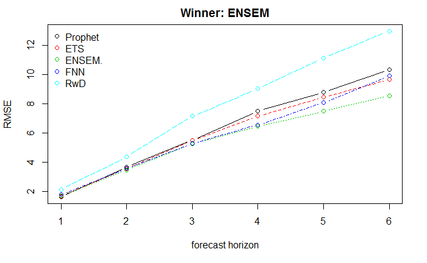

Optimize selected hyperparameters (here scale parameter of Normal and Laplace prior), e.g. Prophet model:

```r
best_params_ba = hyper_optim(y_obs, p_oob=0.85, n.ahead=6, winner = 'PROPHET')
```

```
[1] "Optimize Prophet hyperparameter."
10 points in hyperparameter space were pre-sampled
elapsed = 28.19 Round = 11  changepoint_prior_scale = 0.0515    seasonality_prior_scale = 6.6017    n_changepoints = 4.0000 Value = -9.8069
```

```
[1] "Fitting PROPHET"
```

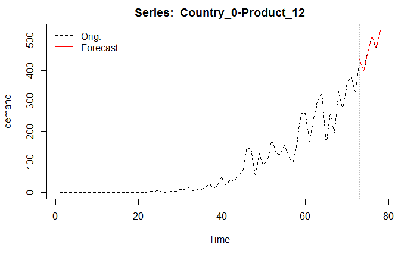

**Model results**

Raw time series, used forecasting model and 6-step ahead forecasts ($T=78$ block):

```r
output78
```

| Country/Product | model | 2012-10 | 2012-11 | 2012-12 | 2013-01 | 2013-02 | 2013-03 | 2013-04 | 2013-05 | 2013-06 | 2013-07 | 2013-08 | 2013-09 | 2013-10 | 2013-11 | 2013-12 | 2014-01 | 2014-02 | 2014-03 | 2014-04 | 2014-05 | 2014-06 | 2014-07 | 2014-08 | 2014-09 | 2014-10 | 2014-11 | 2014-12 | 2015-01 | … |
| --- | --- | --- | --- | --- | --- | --- | --- | --- | --- | --- | --- | --- | --- | --- | --- | --- | --- | --- | --- | --- | --- | --- | --- | --- | --- | --- | --- | --- | --- | --- |
| Country_0 Product_0 | ENSEM | 46 | 208 | 14 | 18 | 6 | 28 | 17 | 15 | 10 | 21 | 23 | 15 | 25 | 221 | 22 | 37 | 144 | 246 | 77 | 73 | 233 | 42 | 107 | 64 | 69 | 40 | 157 | 24 | … |
| Country_0 Product_1 | NNAR | 0 | 0 | 0 | 0 | 0 | 0 | 0 | 0 | 0 | 0 | 0 | 0 | 0 | 0 | 0 | 0 | 0 | 0 | 0 | 0 | 0 | 0 | 0 | 0 | 0 | 0 | 0 | 0 | … |
| Country_0 Product_10 | PROPHET | 0 | 0 | 0 | 0 | 0 | 0 | 0 | 0 | 0 | 0 | 0 | 0 | 0 | 0 | 0 | 0 | 0 | 0 | 0 | 0 | 0 | 0 | 0 | 0 | 0 | 0 | 0 | 0 | … |
| Country_0 Product_11 | ETS | 0 | 0 | 0 | 0 | 0 | 0 | 0 | 46 | 19 | 35 | 25 | 33 | 56 | 74 | 107 | 153 | 62 | 96 | 133 | 205 | 133 | 309 | 248 | 231 | 220 | 305 | 210 | 299 | … |
| Country_0 Product_12 | ENSEM | 0 | 0 | 0 | 0 | 0 | 0 | 0 | 0 | 0 | 0 | 0 | 0 | 0 | 0 | 0 | 0 | 0 | 0 | 0 | 0 | 0 | 0 | 3 | 3 | 6 | 0 | 2 | 4 | … |
| Country_0 Product_13 | PROPHET | 20776 | 32321 | 49780 | 22236 | 10270 | 38911 | 42731 | 40134 | 34897 | 37141 | 34413 | 24464 | 22364 | 44023 | 63938 | 50462 | 24803 | 19360 | 45279 | 39005 | 31569 | 35726 | 41079 | 32586 | 46314 | 32451 | 51318 | 27683 | … |
| Country_0 Product_14 | RWD | 2426 | 4574 | 3367 | 4871 | 2223 | 2417 | 3385 | 3640 | 3284 | 3599 | 2344 | 1298 | 5098 | 2842 | 3736 | 5002 | 1422 | 2290 | 1936 | 2670 | 1593 | 1163 | 828 | 958 | 1052 | 662 | 443 | 647 | … |
| Country_0 Product_16 | NNAR | 2897 | 5381 | 6653 | 5528 | 3683 | 3973 | 8295 | 8186 | 8145 | 7394 | 5966 | 2982 | 8754 | 6239 | 7907 | 8491 | 4164 | 6665 | 5699 | 7023 | 6184 | 7353 | 9325 | 3275 | 7702 | 5735 | 7784 | 5151 | … |
| Country_0 Product_17 | ETS | 143 | 159 | 77 | 80 | 59 | 55 | 109 | 113 | 96 | 209 | 127 | 69 | 127 | 113 | 163 | 170 | 157 | 108 | 134 | 169 | 146 | 150 | 178 | 118 | 168 | 154 | 219 | 139 | … |
| Country_0 Product_2 | ENSEM | 201 | 327 | 403 | 341 | 217 | 223 | 304 | 216 | 348 | 211 | 207 | 300 | 376 | 430 | 460 | 411 | 157 | 184 | 422 | 377 | 437 | 548 | 823 | 161 | 444 | 403 | 373 | 311 | … |

[output cut: 128 more lines]

Raw time series, used forecasting model and 6-step ahead forecasts ($T=42$ block):

```r
output42
```

| Country/Product | model | 2015-10 | 2015-11 | 2015-12 | 2016-01 | 2016-02 | 2016-03 | 2016-04 | 2016-05 | 2016-06 | 2016-07 | 2016-08 | 2016-09 | 2016-10 | 2016-11 | 2016-12 | 2017-01 | 2017-02 | 2017-03 | 2017-04 | 2017-05 | 2017-06 | 2017-07 | 2017-08 | 2017-09 | 2017-10 | 2017-11 | 2017-12 | 2018-01 | … |
| --- | --- | --- | --- | --- | --- | --- | --- | --- | --- | --- | --- | --- | --- | --- | --- | --- | --- | --- | --- | --- | --- | --- | --- | --- | --- | --- | --- | --- | --- | --- |
| Country_0 Product_4 | RWD | 404434 | 338979 | 429631 | 375479 | 476205 | 442663 | 489896 | 439415 | 610121 | 481154 | 668959 | 516346 | 637422 | 600592 | 852966 | 670717 | 548733 | 1125032 | 953171 | 952713 | 865291 | 1134938 | 965139 | 885235 | 996605 | 1027121 | 1274360 | 1093521 | … |
| Country_0 Product_5 | RWD | 33346 | 27280 | 18648 | 19012 | 23068 | 35560 | 33098 | 27714 | 21528 | 46618 | 45920 | 24292 | 36392 | 36884 | 25512 | 52548 | 37550 | 42134 | 47146 | 38868 | 62384 | 76100 | 43996 | 52720 | 50648 | 35152 | 43556 | 53580 | … |
| Country_0 Product_6 | NNAR | 18432 | 28862 | 35079 | 30875 | 33108 | 24913 | 16919 | 25864 | 32759 | 38570 | 39102 | 31176 | 38031 | 32665 | 31374 | 74061 | 53675 | 55593 | 41448 | 36289 | 50511 | 59501 | 52249 | 51019 | 57506 | 69248 | 60200 | 51801 | … |
| Country_0 Product_7 | RWD | 52262 | 30758 | 40872 | 38971 | 55319 | 58176 | 49288 | 74585 | 80932 | 97563 | 143046 | 56737 | 81106 | 85292 | 149705 | 169753 | 147351 | 278022 | 342703 | 291849 | 187971 | 203556 | 270467 | 117337 | 200353 | 389939 | 273080 | 281741 | … |
| Country_0 Product_8 | ETS | 714938 | 935633 | 1038493 | 713877 | 611168 | 860211 | 696990 | 768663 | 773654 | 622678 | 1063453 | 739814 | 854632 | 894743 | 877417 | 1030029 | 497424 | 744315 | 730610 | 980383 | 693105 | 1023114 | 894411 | 743385 | 974179 | 888564 | 1265228 | 1631716 | … |
| Country_10 Product_4 | RWD | 57013 | 53523 | 55808 | 39630 | 44924 | 67520 | 52990 | 46420 | 71942 | 51706 | 51466 | 57612 | 58901 | 72127 | 62024 | 58108 | 48365 | 56397 | 41840 | 58989 | 53538 | 48162 | 76587 | 50716 | 55278 | 68655 | 50193 | 70129 | … |
| Country_10 Product_5 | ETS | 15884 | 19624 | 13148 | 11202 | 18474 | 11848 | 14068 | 11304 | 16184 | 12940 | 10756 | 13128 | 15444 | 14466 | 9760 | 17492 | 9348 | 13784 | 9600 | 7318 | 14180 | 6524 | 11010 | 11812 | 10804 | 6588 | 5992 | 12528 | … |
| Country_10 Product_6 | ETS | 14723 | 14214 | 9214 | 17730 | 21454 | 17489 | 17585 | 12901 | 17017 | 17024 | 11245 | 16500 | 20708 | 19646 | 13698 | 14020 | 16542 | 12240 | 10569 | 16415 | 10840 | 14694 | 12191 | 20262 | 13907 | 18136 | 16184 | 16002 | … |
| Country_10 Product_7 | ENSEM | 8382 | 9770 | 7957 | 9502 | 11479 | 16359 | 16772 | 8954 | 14013 | 10680 | 10364 | 10349 | 14165 | 12004 | 14663 | 15718 | 13054 | 14767 | 14146 | 17641 | 9196 | 11190 | 20674 | 16809 | 18545 | 23177 | 15796 | 12744 | … |
| Country_10 Product_8 | RWD | 60010 | 57564 | 52988 | 57374 | 44781 | 54970 | 45129 | 52623 | 67238 | 60174 | 61663 | 57151 | 44670 | 56017 | 41334 | 41174 | 35980 | 25147 | 33954 | 69514 | 35472 | 48050 | 49868 | 48113 | 49817 | 37923 | 24159 | 46141 | … |

[output cut: 50 more lines]

**Next steps:**

- In a Box-Jenkins modeling paradigm: model (residual) diagnosis $\rightarrow$ respecify/retrain?
- Business-wise:
  - Model serving: 1.) build REST API (e.g. using Plumber) to trigger model, 2.) package model, 3.) deploy whole package in Docker container
  - set up backtesting system (e.g. via Shiny) to get alarm in case the model would decrease from estimated OOB error (over some time period, $s=6,12...$).
  - Get feedback from users $\rightarrow$ model refinement